# Part II - Prosper Loan Data Analysis

## Investigation Overview

The overall goal of this presentation is to provide a comprehensive analysis of the relationships between borrower rates, credit scores, loan terms, and homeownership status. The aim is to identify and elucidate key patterns and interactions that influence borrower rates, thereby offering valuable insights for both borrowers and lenders. This analysis helps in understanding how various factors affect loan terms and borrower risk profiles, enabling better decision-making and risk assessment in the lending process.

## Dataset Overview

The dataset under analysis comprises detailed information on 83,982 loans, with each loan characterized by several key variables such as loan term, borrower rate, Prosper rating, homeownership status, and credit scores. This data provides a comprehensive view of borrower behavior and loan performance, enabling a detailed exploration of the factors influencing borrower rates.

**Key Variables**

- **Term**: Loan term in months (e.g., 12, 36, or 60 months).
- **BorrowerRate**: The interest rate charged to the borrower.
- **ProsperRating (Alpha)**: A proprietary credit rating assigned by Prosper, ranging from AA (lowest risk) to HR (highest risk).
- **IsBorrowerHomeowner**: A boolean indicating whether the borrower is a homeowner.
- **CreditScore**: An average of the lower and upper bounds of the borrower’s credit score range.

## Executive Summary

The following key insights have been derived from the analysis of the dataset and will be supported by the visualizations:

**Borrower Rate and Credit Score**: Borrower rates generally decrease as credit scores increase, indicating lower risk for higher credit scores. This relationship is consistent for both homeowners and non-homeowners, emphasizing the importance of maintaining a high credit score.

**Borrower Rate and Loan Term**: Short-term loans (12 months) have lower borrower rates with less variability. Medium-term loans (36 months) show higher and more variable rates. Long-term loans (60 months) have rates close to 36-month loans but with less variability, suggesting stringent lending criteria for long-term loans.

**Prosper Rating and Homeownership**: Homeowners have better Prosper Ratings (AA, A, B), reflecting financial stability and lower risk. Non-homeowners have lower ratings (C, D, E, HR), indicating higher perceived risk. Homeownership is associated with better credit ratings and more favorable lending terms.

**Credit Scores and Borrower Rate for Homeowners vs. Non-Homeowners**: Homeowners generally receive lower borrower rates, particularly for credit scores under 680, due to the additional security provided by their homes. Non-homeowners face higher borrower rates overall, but those with high credit scores (> 720) can receive lower rates than their homeowner counterparts, likely due to their excellent credit history and better financial conditions without the burden of mortgage payments. For mid-range credit scores (680-720), there is minimal difference in borrower rates between homeowners and non-homeowners, suggesting that lenders assess risk similarly in this range.

### Importing Libraries and Loading Data

```python
# import all packages and set plots to be embedded inline
import numpy as np
import pandas as pd
import matplotlib.pyplot as plt
from matplotlib.ticker import FuncFormatter
import seaborn as sns


# suppress warnings from final output
import warnings
warnings.simplefilter("ignore")
```

```python
# Load the cleaned dataset from a CSV file into a pandas DataFrame.
df_clean = pd.read_csv('df_clean.csv')
```

By executing the above steps, we ensure that the necessary libraries are imported, the cleaned data is loaded

## Visualization and Analysis

### Relationship Between Credit Score and Borrower Rate

This scatter plot with a regression line depicts the relationship between a borrower's credit score and the borrower rate (interest rate) they are charged. The plot is designed to investigate how credit scores influence the interest rates offered to borrowers.

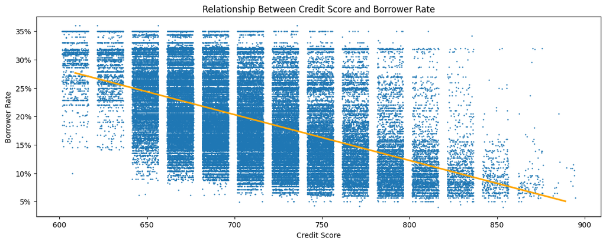

```python
# Define the to_percentage function
def to_percentage(y, position):
    # Convert to percentage
    return f'{y * 100:.0f}%'

# set plot dimensions
plt.figure(figsize=(14,5))

sns.regplot(data=df_clean, x='CreditScore', y='BorrowerRate', x_jitter=7.5, scatter_kws={'s':1}, line_kws={'color':'orange'})
plt.xlabel('Credit Score')
plt.ylabel('Borrower Rate')
plt.title('Relationship Between Credit Score and Borrower Rate')
plt.gca().yaxis.set_major_formatter(FuncFormatter(to_percentage));
```

**Purpose**:

- The purpose of this visualization is to explore the relationship between credit scores and the interest rates charged to borrowers. By examining this relationship, we can gain insights into how credit risk assessment affects lending practices.

**Observations**:

- **Negative Relationship**: The scatter plot reveals a clear negative relationship between Credit Score and Borrower Rate. As the credit score increases, the borrower rate generally decreases.
- **Trend Consistency**: The points are spread around the regression line, indicating some variability in the data. However, the overall trend is consistent with higher credit scores being associated with lower borrower rates.
- **Risk and Rates**: This observed relationship aligns with expectations. Borrowers with higher credit scores are considered lower risk, which results in lower interest rates being offered to them.

**Interpretation**:

The scatter plot with the regression line shows a clear negative relationship between Credit Score and BorrowerRate. As the credit score increases, the borrower rate generally decreases, indicating that borrowers with higher credit scores are charged lower interest rates. The points are spread around the regression line, showing some variability, but the overall trend is consistent. This relationship aligns with expectations, as higher credit scores typically indicate lower risk, resulting in lower interest rates for borrowers.

### Variation of Borrower Rates Across Different Loan Terms

This box plot shows the distribution of borrower rates (interest rates) across different loan terms: 12 months, 36 months, and 60 months. The plot is designed to investigate how interest rates vary based on the duration of the loan.

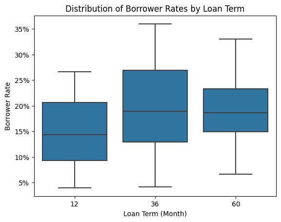

```python
# Create a box plot to visualize the distribution of Borrower Rates by Loan Term
sns.boxplot(data=df_clean, x='Term', y='BorrowerRate', color='tab:blue')

# Labeling the x-axis as 'Loan Term (Month)'
plt.xlabel('Loan Term (Month)')

# Labeling the y-axis as 'Borrower Rate'
plt.ylabel('Borrower Rate')

# Formatting the y-axis to display percentages
from matplotlib.ticker import FuncFormatter

def to_percentage(y, position):
    # Converts a number to a percentage format
    return f'{y * 100:.0f}%'

# Adding a title to the box plot
plt.title('Distribution of Borrower Rates by Loan Term')

# Apply the percentage format to the y-axis
plt.gca().yaxis.set_major_formatter(FuncFormatter(to_percentage));
```

**Purpose**:

The purpose of this visualization is to explore the variation in borrower rates across different loan terms. Understanding this variation can provide insights into how lenders assess risk and set interest rates based on the loan duration.

**Observations**:

- **12-Month Loans**: The borrower rates for 12-month loans are relatively lower with a median around 15%. The interquartile range (IQR) is narrow, indicating less variability in the rates.
- **36-Month Loans**: The borrower rates for 36-month loans are higher, with a median around 20%. The IQR is wider, indicating more variability and the presence of some higher interest rates.
- **60-Month Loans**: The median borrower rate for 60-month loans is very close to that of 36-month loans, but the IQR is the narrowest. This indicates small variability and more consistent rates compared to 36-month loans.

**Interpretation**:

This pattern suggests that lenders charge higher interest rates for 36-month and 60-month loans due to the higher risk associated with a longer payback period. The lower variability in the 60-month loan rates could be due to stricter lending criteria or a more selective borrower pool, resulting in more consistent risk assessments and interest rates.

### Relationship Between Prosper Ratings and Borrower Homeownership Status

This heatmap shows the percentage distribution of Prosper Ratings between homeowners and non-homeowners. It visually represents how credit ratings vary depending on whether a borrower owns a home or not.

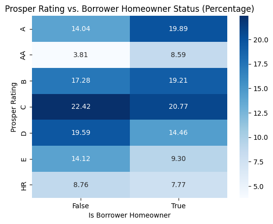

```python
# Grouping the data and creating a pivot table
ct_counts = df_clean.groupby(['ProsperRating (Alpha)', 'IsBorrowerHomeowner']).size().reset_index(name='count')
ct_counts = ct_counts.pivot(index='ProsperRating (Alpha)', columns='IsBorrowerHomeowner', values='count')

# Calculating the percentage for each column
ct_counts_percentage = ct_counts.div(ct_counts.sum(axis=0), axis=1) * 100

# Creating the heatmap
sns.heatmap(ct_counts_percentage, annot=True, fmt='.2f', cmap='Blues')
plt.xlabel('Is Borrower Homeowner')
plt.ylabel('Prosper Rating')
plt.title('Prosper Rating vs. Borrower Homeowner Status (Percentage)');
```

**Purpose**:

The purpose of this visualization is to compare the credit risk profiles of homeowners and non-homeowners by analyzing the distribution of Prosper Ratings. This helps in understanding how homeownership status influences credit ratings and perceived risk.

**Observations**:

- Homeowners generally have higher percentages in the better Prosper Ratings (AA, A, B). For example, 8.59% of homeowners have an AA rating compared to 3.81% of non-homeowners. Homeowners also show higher percentages in A and B ratings.
- Non-homeowners have higher percentages in the lower Prosper Ratings (C, D, E, HR). For instance, 22.42% of non-homeowners have a C rating compared to 20.77% of homeowners. Non-homeowners also have higher percentages in D and E ratings.
- The trend indicates that homeownership is associated with better credit ratings, reflecting more financial stability and lower perceived risk by lenders.

**Interpretation**:

Prosper Rating significantly varies with homeownership status. Homeowners generally have better Prosper Ratings (AA, A, B), reflecting their financial stability and lower risk profile. For instance, 8.59% of homeowners have an AA rating compared to only 3.81% of non-homeowners. Non-homeowners, on the other hand, tend to have lower Prosper Ratings (C, D, E, HR), indicating higher perceived risk. The absence of homeownership is seen as a higher risk factor, resulting in lower credit ratings. This relationship highlights the impact of homeownership on creditworthiness, with homeowners typically enjoying higher credit ratings and more favorable lending terms. The visualization effectively communicates how homeownership correlates with better credit ratings, providing insights into the financial stability and risk profiles of these groups.

### Variation of Borrower Rate Across Different Loan Terms for Homeowners and Non-Homeowners

This box plot shows the distribution of borrower rates for different loan terms (12-month, 36-month, 60-month) and compares homeowners with non-homeowners. Each box plot represents the median, interquartile range (IQR), and outliers of borrower rates for a specific loan term and homeownership status.

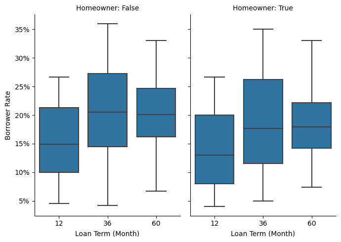

```python
# Determine the unique values for 'Term' to specify the order
term_order = sorted(df_clean['Term'].unique())

# Creating the FacetGrid
g_1 = sns.FacetGrid(data=df_clean, col='IsBorrowerHomeowner', height=5, aspect=0.7)
g_1.map(sns.boxplot, 'Term', 'BorrowerRate', order=term_order, color='tab:blue')

# Formatting the y-axis to display percentages
def to_percentage(y, position):
    # Converts a number to a percentage format
    return f'{y * 100:.0f}%'

for ax in g_1.axes.flatten():
    ax.yaxis.set_major_formatter(FuncFormatter(to_percentage))

# Customizing the facet titles
g_1.set_titles(col_template='Homeowner: {col_name}')

# Adding the titles
g_1.set_axis_labels('Loan Term (Month)', 'Borrower Rate');
```

**Purpose**:

The purpose of this visualization is to analyze and compare the distribution of borrower rates across different loan terms for homeowners and non-homeowners. This helps in understanding the impact of homeownership on the interest rates offered by lenders and how loan terms influence these rates.

**Observations**:

Homeowners:

- 12-Month Loans: The median borrower rate is around 13%, with an interquartile range (IQR) from 8% to 20%.
- 36-Month Loans: The median borrower rate is around 18%, with an IQR from 12% to 27%.
- 60-Month Loans: The median borrower rate is around 19%, with an IQR from 15% to 22%.

Non-Homeowners:

- 12-Month Loans: The median borrower rate is around 15%, with an IQR from 10% to 22%.
- 36-Month Loans: The median borrower rate is around 21%, with an IQR from 15% to 27%.
- 60-Month Loans: The median borrower rate is around 20%, with an IQR from 16% to 25%.

### Borrower Rate vs. Credit Score for Different Homeownership Status

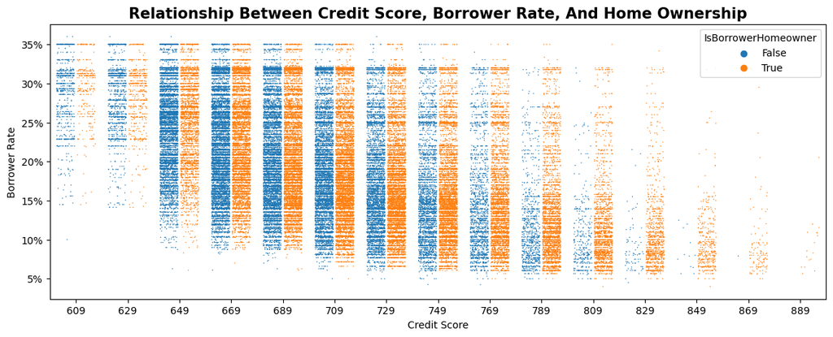

```python
# Define the to_percentage function
def to_percentage(y, position):
    # Convert y-axis values to percentage format
    return f'{y * 100:.0f}%'

# Set plot dimensions to 14 inches by 5 inches
plt.figure(figsize=(14,5))

sns.stripplot(data=df_clean,
              x='CreditScore', y='BorrowerRate', hue='IsBorrowerHomeowner',
              size=1, jitter=0.35, dodge=True)

# Set the title of the plot with customized font size and weight
plt.title('Relationship between Credit Score, Borrower Rate, and home ownership'.title(), fontsize=15, fontweight='bold')

# Set the x-axis label and capitalize it
plt.xlabel('Credit Score'.title())

# Set the y-axis label and capitalize it
plt.ylabel('Borrower Rate'.title())

# Apply the percentage formatter to the y-axis
plt.gca().yaxis.set_major_formatter(FuncFormatter(to_percentage))

# Display the plot
plt.show();
```

**Purpose**:

The purpose of this visualization is to analyze and compare the relationship between borrower rates and credit scores for homeowners and non-homeowners. It helps in understanding how homeownership status impacts the interest rates charged to borrowers with different credit scores.

**Observations**:

- Relationship with Credit Score: For both homeowners and non-homeowners, borrower rates generally decrease as credit scores increase. This indicates that higher credit scores, which suggest better creditworthiness, result in lower interest rates for both groups.
- Credit Score Distribution: Homeowners tend to have better credit scores than non-homeowners overall. The scatter plot shows a higher concentration of homeowners with credit scores above 700 compared to non-homeowners.
- Borrower Rate Differences: For credit scores under 680, homeowners benefit from lower borrower rates compared to non-homeowners due to the collateral provided by homeownership. Between 680 and 720, borrower rates are similar for both groups, indicating a more uniform risk assessment by lenders. For credit scores over 720, non-homeowners enjoy lower borrower rates, potentially due to their good credit history without mortgage burdens, leading to better financial conditions and lower perceived risk.

**Interpretation**:

Homeownership provides collateral and signifies financial stability, which can lower borrower rates, especially for lower credit scores. This interaction strengthens the relationship between credit score and borrower rate for homeowners. For non-homeowners with high credit scores, the lack of mortgage payments may lead to better financial conditions and lower perceived risk. This strengthens the positive impact of high credit scores on securing lower borrower rates.

It was surprising to find that non-homeowners with high credit scores (above 720) receive lower borrower rates than homeowners with the same credit score. This suggests that lenders may place a higher value on an excellent credit history and financial management skills over the presence of collateral (homeownership) in these cases. This challenges the conventional wisdom that homeownership is always a primary factor in securing the best loan terms.

Another surprising interaction was the minimal difference in borrower rates between homeowners and non-homeowners for mid-range credit scores (680-720). This indicates that in this range, credit score alone is a strong predictor of risk, and the additional factor of homeownership does not significantly influence the borrower rates. This uniformity suggests that lenders may have a more standardized approach to assessing risk for borrowers in this credit score bracket, regardless of their homeownership status.